# GEO-notebook

Waleed Khan

2022-09-01

## Introduction

With the increasing access to large microarray datasets for a wide range of disease states, the possibility for advanced computational analysis using methods such as principal component analysis opens the door for new insight into underlying mechanisms of diseases.

The data used was obtained through DNA microarrays and data-sets were retrieved from NCBI’s Genome Expression Omnibus public repository (Barrett et al, 2013). The dataset in question came from a study that investigated blood samples of individuals infected with dengue virus and during convalescence (Kwissa et al, 2014). By exploring the dataset and identifying significant differences in genes expression between healthy and diseased individuals, key insights can be made into the response mechanisms of hosts infected with dengue virus.

## Loading in and initatial wrangling of data

In order to retrieve the data-set from the database, BioConductor’s GEOquery package was used (Davis & Meltzer, 2007). GDS2eset() can extract the expression data from the gse dataset, while pData() retrieves information about samples.

```r
gse <- getGEO("GDS5093", GSEMatrix = TRUE)
X <- Table(gse)
eset <- GDS2eSet(gse, do.log2=TRUE)
pDat <- pData(eset)
```

Avereps() averages duplicates based on row names.

```r
geneNames <- as.character(X$IDENTIFIER)
X <- exprs(eset)
rownames(X) <- geneNames
ave_X <- avereps(X, ID = rownames(X))
```

## Hierarchical clustering analysis (HCA)

Hierarchical clustering analysis (HCA) was performed using the stats package found in the core R library. A distance matrix was produced for the samples using the dist() function using the “euclidian” method. Following this, clustering was performed via hclust() function using the “complete” method.

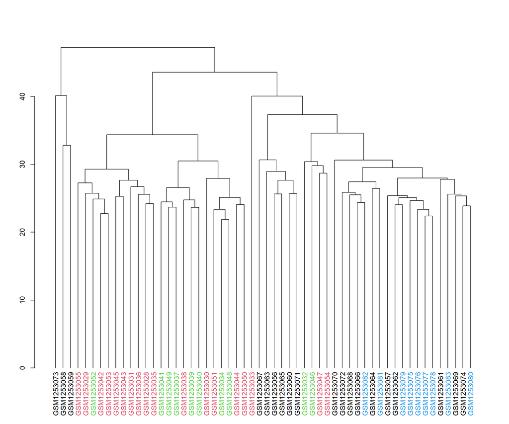

Euclidian method was used as the data were presented as continuous numerical values, and data points are scaled appropriately. Complete-linkage was used as it clusters based on furthest distance between data points in separate clusters and tends to be more suited in terms of time complexity and the dimensionality of the dataset (Schütze et al, 2008). A dendrogram was produced showing clustering of the samples using the dendextend package. This process was repeated similarly for the 100 genes with the highest standard deviation, as these genes could be inferred to have the most difference in expression profiles between samples. The same parameters were used for calculating the distance matrix and clustering, and a dendrogram was produced.

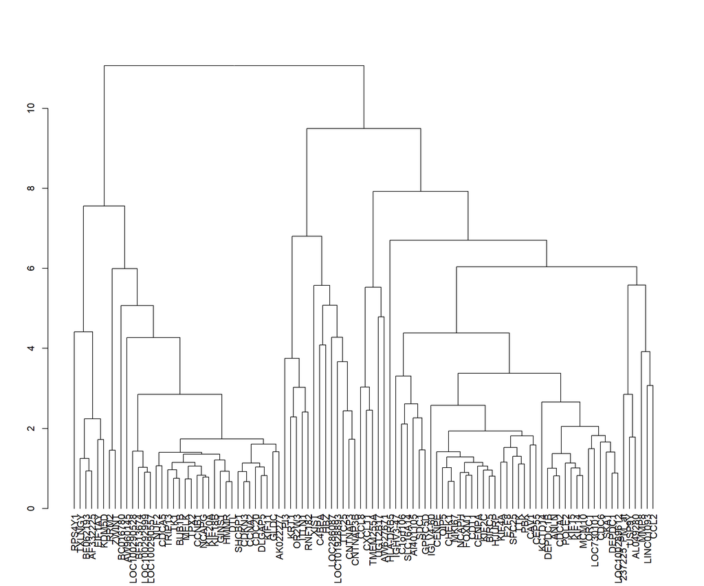